# Homework3

Chen Yi-Ju(Ernie)

2020/6/4

## Question 7.1

### Describe a situation or problem from your job, everyday life, current events, etc., for which exponential smoothing would be appropriate. What data would you need? Would you expect the value of α (the first smoothing parameter) to be closer to 0 or 1, and why?

I would consider oil price being a good situation to use exponential smoothing. α would be somewhere closer to 1 than 0 because the oil price(under current situations) are known to have big fluncuations due to random events happening.

## Question 7.2

### Using the 20 years of daily high temperature data for Atlanta (July through October) from Question 6.2 (file temps.txt), build and use an exponential smoothing model to help make a judgment of whether the unofficial end of summer has gotten later over the 20 years.

### My answer is No. According to exponential smoothing, summer has not gotten latter over the 20 years.This is the proccess for proving it.

Setup:

```r
setwd("D:/ernie/self-study/GTxMicroMasters/Introduction to Analytics Modeling/week3/homework")
library(magrittr)
library(tidyverse)
library(lubridate)
library(corrplot)
library(leaps)
```

turning data into time. series format

```r
weather <- data.frame(read.table("temps.txt" , header = T))%>%
  select(.,- DAY) %>%
  unlist()%>%
  as.vector()%>%
  ts(start = 1996 , end = 2015 , frequency = 100)
```

Graphically represented: It is hard to see actual trends

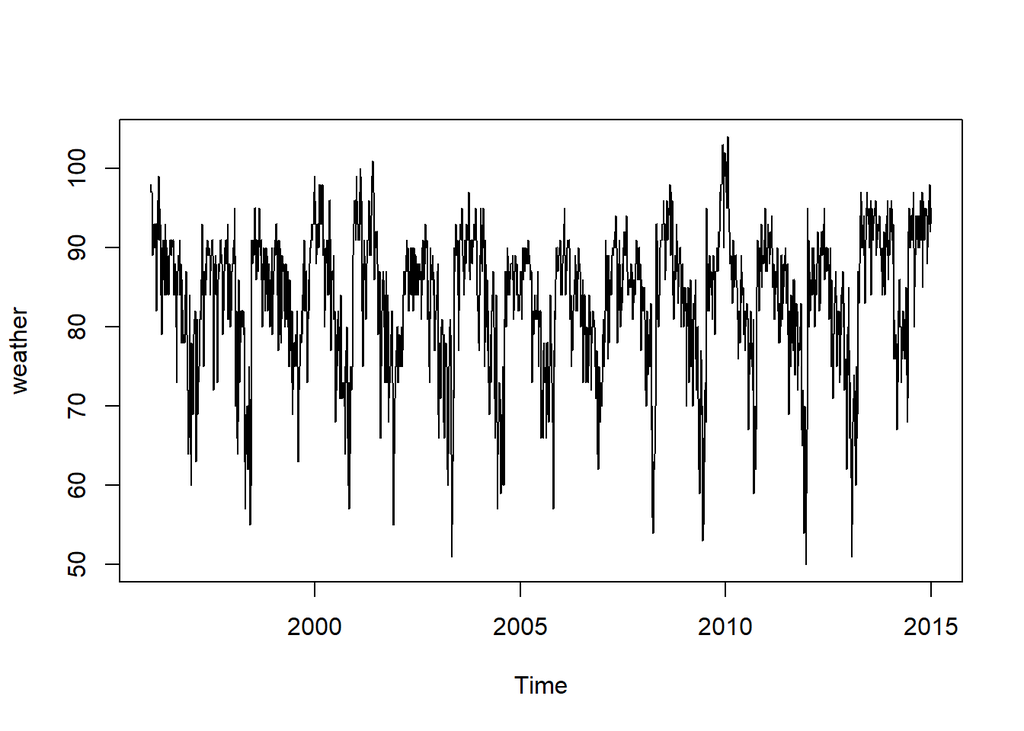

```r
plot(weather)
```

Putting down the HoltWinters Function

```r
HoltWinters(weather)
```

```
## Holt-Winters exponential smoothing with trend and additive seasonal component.
##
## Call:
## HoltWinters(x = weather)
##
## Smoothing parameters:
##  alpha: 0.7015953
##  beta : 0
##  gamma: 0.6813504
##
## Coefficients:
##              [,1]
## a    102.12556505
## b     -0.01546985
## s1   -10.48519724
## s2   -12.44318212
## s3   -10.99764581
## s4   -12.75209947
## s5   -12.62974056
## s6   -11.29182605
## s7   -10.93658628
## s8    -5.40303859
## s9    -6.79845771
## s10   -3.39388173
## s11   -6.86132351
## s12   -6.30334825
## s13   -9.27608984
## s14   -8.60454327
## s15   -9.35894641
## s16  -11.98293559
## s17  -10.08152712
## s18   -5.73359214
## s19   -4.21236012
## s20   -6.33379226
## s21   -5.18509908
## s22   -1.14584131
## s23   -2.59594123
## s24   -2.24708371
## s25   -1.20692084
## s26    1.98058414
```

[output cut: 59 more lines]

```
## s86    0.17466496
## s87    0.76124762
## s88    3.07396243
## s89    2.29772241
## s90   -0.13094343
## s91   -0.94184454
## s92   -1.16934790
## s93   -1.93458425
## s94   -5.57050542
## s95  -11.59120257
## s96   -7.82643736
## s97   -3.97388600
## s98   -7.74355298
## s99   -5.55287173
## s100  -7.58855363
```

The main focus is here :  
Smoothing parameters:  
alpha: 0.7015953 beta : 0 gamma: 0.6813504

the beta of the Holt Winters Function is 0, indicating no overall trend, which matches our intuition.

## Question 8.1

### Describe a situation or problem from your job, everyday life, current events, etc., for which a linear regression model would be appropriate. List some (up to 5) predictors that you might use.

A good opportunity would be predicting a baseball team’s winning chances. It would be through parameters including:  
team average ERA(Earned run average)  
team average batting average  
team average slugging average  
and team average fielding percentage.

## Question 8.2

### Using crime data , use regression (a useful R function islm or glm) to predict the observed crime rate in a cityin a city with the following data:

M = 14.0  
So = 0  
Ed = 10.0  
Po1 = 12.0  
Po2 = 15.5  
LF = 0.640  
M.F = 94.0  
Pop = 150  
NW = 1.1  
U1 = 0.120  
U2 = 3.6  
Wealth = 3200  
Ineq = 20.1  
Prob = 0.04  
Time = 39.0  
Show your model (factors used and their coefficients), the software output, and the quality of fit.

Read Data

```r
crime <- read.table("uscrime.txt" , header = TRUE)%>%
  data.frame()
```

Showing the correlation between predictors

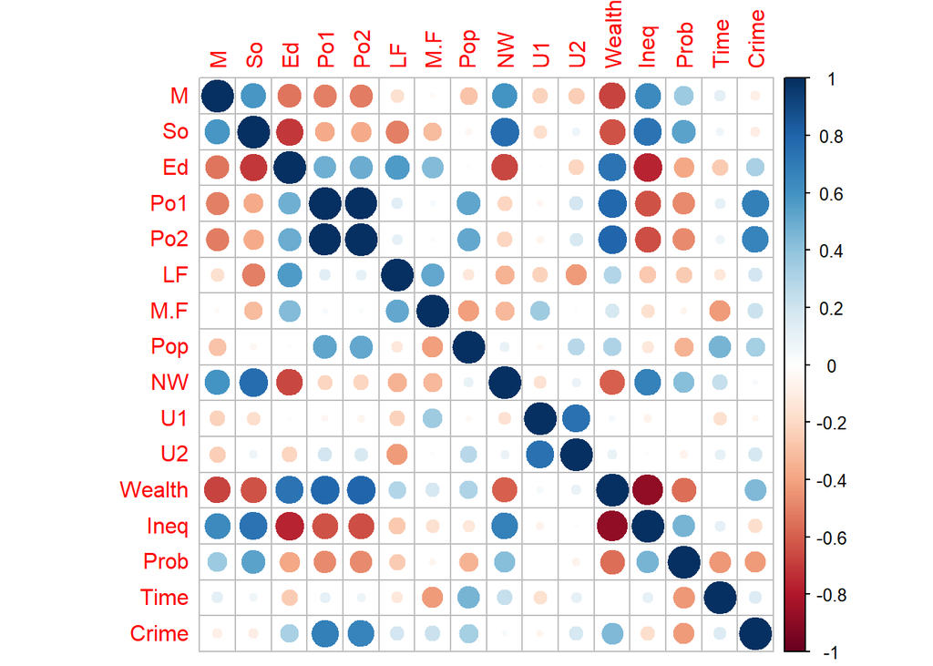

```r
pl1 <- corrplot(cor(crime))
```

We eliminate predictor P02 due to its high correlation with p01

Numeric and Graphical representation of correlation with the crime variable

```r
cor_relation <- abs(cor(crime$Crime , crime[,1:15]))%>%
  data.frame()
cor_relation <- cor_relation%>%
  gather(predictor, correlation)
cor_relation
```

```
##    predictor correlation
## 1          M  0.08947240
## 2         So  0.09063696
## 3         Ed  0.32283487
## 4        Po1  0.68760446
## 5        Po2  0.66671414
## 6         LF  0.18886635
## 7        M.F  0.21391426
## 8        Pop  0.33747406
## 9         NW  0.03259884
## 10        U1  0.05047792
## 11        U2  0.17732065
## 12    Wealth  0.44131995
## 13      Ineq  0.17902373
## 14      Prob  0.42742219
## 15      Time  0.14986606
```

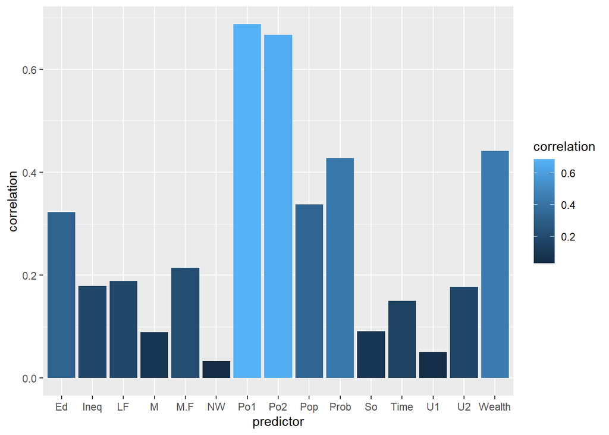

```r
pl2 <- ggplot(data = cor_relation, aes( x  = predictor , y = correlation , fill = correlation )) +
  geom_col()
pl2
```

Constructing the model:

```r
model <- lm (data = crime , Crime ~ Ed + Ineq + LF + M + M.F +Po1 + Pop + Prob  + Time + Ed)
summary(model)
```

```
##
## Call:
## lm(formula = Crime ~ Ed + Ineq + LF + M + M.F + Po1 + Pop + Prob +
##     Time + Ed, data = crime)
##
## Residuals:
##     Min      1Q  Median      3Q     Max
## -468.62 -100.73   -6.44  139.91  520.35
##
## Coefficients:
##               Estimate Std. Error t value Pr(>|t|)
## (Intercept) -5189.5782  1460.9341  -3.552 0.001063 **
## Ed            140.9730    57.8900   2.435 0.019823 *
## Ineq           68.7477    15.8765   4.330 0.000109 ***
## LF           -609.2340  1065.0117  -0.572 0.570751
## M              68.3357    35.3331   1.934 0.060784 .
## M.F            17.8666    15.2790   1.169 0.249738
## Po1           126.5215    17.3893   7.276 1.22e-08 ***
## Pop            -0.6526     1.2716  -0.513 0.610833
## Prob        -4006.6838  2033.8562  -1.970 0.056359 .
## Time            1.7858     6.6248   0.270 0.788995
## ---
## Signif. codes:  0 '***' 0.001 '**' 0.01 '*' 0.05 '.' 0.1 ' ' 1
##
## Residual standard error: 213.8 on 37 degrees of freedom
## Multiple R-squared:  0.7543, Adjusted R-squared:  0.6945
## F-statistic: 12.62 on 9 and 37 DF,  p-value: 7.275e-09
```

The summary results show that R- squared is at about 75% which is a good enough result. One thing to notice is however the Variables LF,M.F., Pop and Time are not statistically significant.  
Nevertheless, We test out the model using the given numbers:

```r
test <- data.frame(   M = 14.0,So = 0,Ed = 10.0,Po1 = 12.0,
                      Po2 = 15.5,LF = 0.640,M.F = 94.0 ,Pop = 150,
                      NW = 1.1,U1 = 0.120,U2 = 3.6,Wealth = 3200,Ineq = 20.1,Prob = 0.04,Time = 39.0
                      )
predict(model,test)
```

```
##        1
## 1177.978
```

Therefore my prediction is 1177.978.